# Bajo peso al nacer en Guatemala

- Mostrar todo el código
- Ocultar todo el código
- Ver el código fuente

Exploración inicial de datos, 2009–2024

Autor

Luis Villaseñor

Fecha de publicación

16 de noviembre de 2026

**NotaSobre los datos**

Este informe utiliza **registros generados artificialmente con fines docentes y de reproducibilidad**. Ninguna observación corresponde a una persona real y los resultados no deben interpretarse como estimaciones oficiales de Guatemala.

## Contexto

El bajo peso al nacer es un indicador relevante de salud maternoinfantil. En este proyecto se exploran patrones temporales, estacionales y territoriales del peso al nacer y del bajo peso al nacer en Guatemala entre 2009 y 2024.

La base inicial contiene **100.000 nacimientos ficticios** generados mediante un script reproducible con semilla fija. Después de aplicar los criterios definidos de calidad y elegibilidad, la muestra analítica contiene **97.700 registros**.

### Preguntas exploratorias

Esta primera aproximación busca responder:

1. ¿Cómo se distribuye el peso al nacer en la muestra analítica?
2. ¿Cómo cambia la prevalencia de bajo peso al nacer entre 2009 y 2024?
3. ¿Existe un patrón estacional según el mes de nacimiento?
4. ¿Se observan diferencias entre departamentos y grupos de edad materna?

## De la base simulada a la muestra analítica

Se excluyeron **2.300 registros** de la base inicial por peso desconocido, peso extremo, fecha de nacimiento desconocida o residencia materna desconocida. El flujo completo se generó mediante `02_scripts/02_preparar_base_analitica.R`.

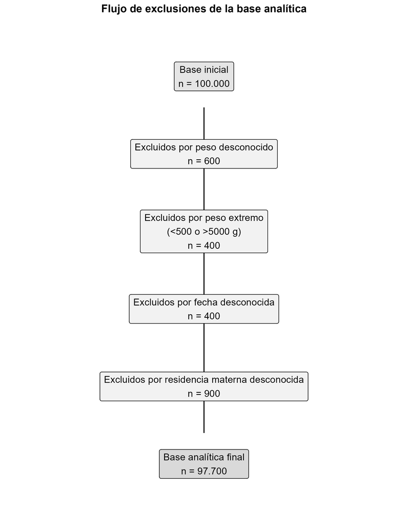

Figura 1: Flujo de exclusiones aplicado para construir la muestra analítica.

Como se observa en Figura 1, el objetivo de la limpieza es retirar únicamente los registros que no cumplen los criterios necesarios para esta exploración.

## Una primera mirada al peso al nacer

En la muestra analítica, el peso medio al nacer es de **3100 g** y la mediana de **3147 g**. La prevalencia global de bajo peso al nacer es de **11.7 %**.

**Ver código**

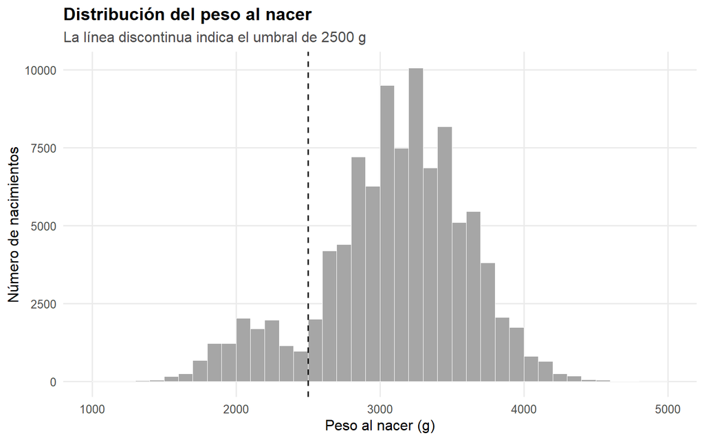

Figura 2: Distribución del peso al nacer en la muestra analítica.

```r
ggplot(
  base,
  aes(x = birth_weight_g)
) +
  geom_histogram(
    binwidth = 100,
    boundary = 0,
    fill = "grey65",
    colour = "white",
    linewidth = 0.2
  ) +
  geom_vline(
    xintercept = 2500,
    linetype = "dashed",
    linewidth = 0.7
  ) +
  labs(
    x = "Peso al nacer (g)",
    y = "Número de nacimientos",
    title = "Distribución del peso al nacer",
    subtitle = "La línea discontinua indica el umbral de 2500 g"
  ) +
  tema_grafico
```

La distribución de Figura 2 permite situar visualmente el punto de corte de 2500 g utilizado para definir el desenlace principal.

## Tendencia temporal

**Ver código**

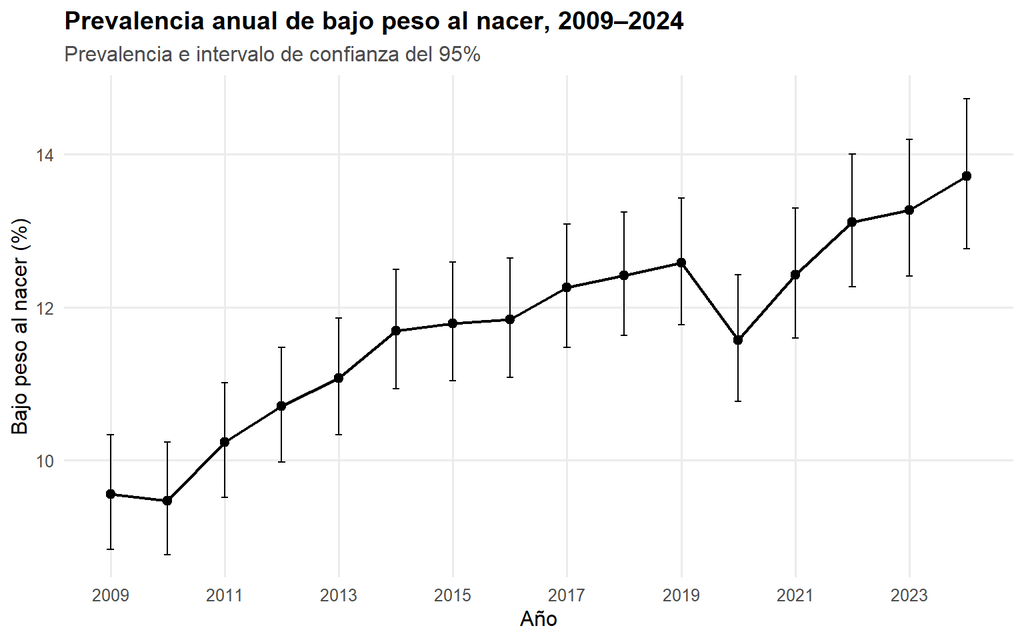

Figura 3: Prevalencia anual de bajo peso al nacer entre 2009 y 2024.

```r
resumen_anual <- resumir_lbw(
  base,
  birth_year
)

ggplot(
  resumen_anual,
  aes(
    x = birth_year,
    y = prevalencia
  )
) +
  geom_errorbar(
    aes(
      ymin = li95,
      ymax = ls95
    ),
    width = 0.12,
    linewidth = 0.45
  ) +
  geom_line(
    linewidth = 0.75
  ) +
  geom_point(
    size = 2.1
  ) +
  scale_x_continuous(
    breaks = seq(
      2009,
      2024,
      by = 2
    )
  ) +
  labs(
    x = "Año",
    y = "Bajo peso al nacer (%)",
    title = "Prevalencia anual de bajo peso al nacer, 2009–2024",
    subtitle = "Prevalencia e intervalo de confianza del 95%"
  ) +
  tema_grafico
```

La Figura 3 muestra una evolución temporal ascendente de la prevalencia simulada, aunque con variaciones entre años. Esta tendencia forma parte de los patrones incorporados deliberadamente durante la generación de los datos y, por lo tanto, debe interpretarse únicamente como material para practicar el análisis reproducible.

## Otros patrones exploratorios

Las siguientes visualizaciones se agrupan en pestañas para comparar distintos aspectos de la base sin alargar innecesariamente el documento.

**Estacionalidad**

**Ver código**

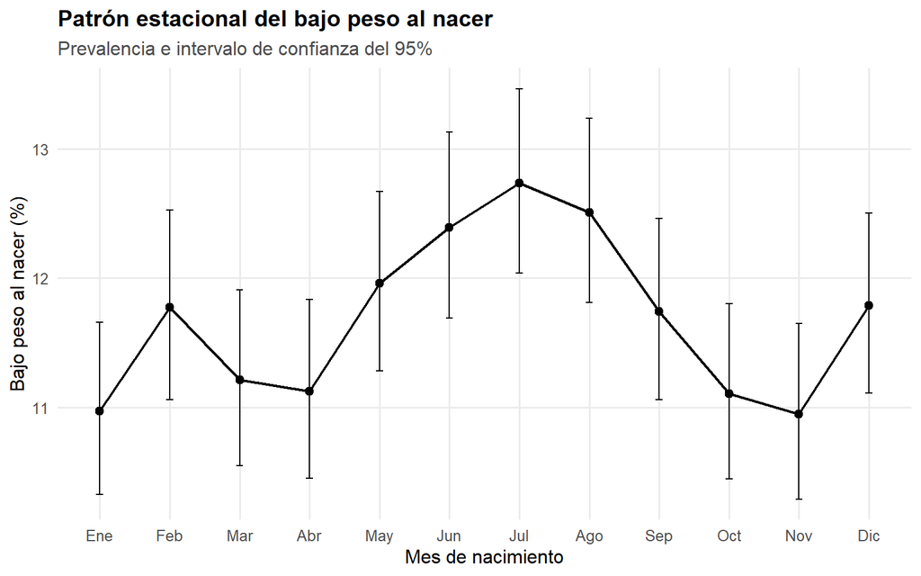

Figura 4: Prevalencia de bajo peso al nacer según mes de nacimiento.

```r
resumen_mensual <- resumir_lbw(
  base,
  birth_month
)

meses <- c(
  "Ene", "Feb", "Mar", "Abr",
  "May", "Jun", "Jul", "Ago",
  "Sep", "Oct", "Nov", "Dic"
)

ggplot(
  resumen_mensual,
  aes(
    x = birth_month,
    y = prevalencia
  )
) +
  geom_errorbar(
    aes(
      ymin = li95,
      ymax = ls95
    ),
    width = 0.10,
    linewidth = 0.45
  ) +
  geom_line(
    linewidth = 0.75
  ) +
  geom_point(
    size = 2.1
  ) +
  scale_x_continuous(
    breaks = 1:12,
    labels = meses
  ) +
  labs(
    x = "Mes de nacimiento",
    y = "Bajo peso al nacer (%)",
    title = "Patrón estacional del bajo peso al nacer",
    subtitle = "Prevalencia e intervalo de confianza del 95%"
  ) +
  tema_grafico
```

En Figura 4 se explora si la frecuencia de bajo peso al nacer presenta un patrón sistemático a lo largo del año.

**Departamento**

**Ver código**

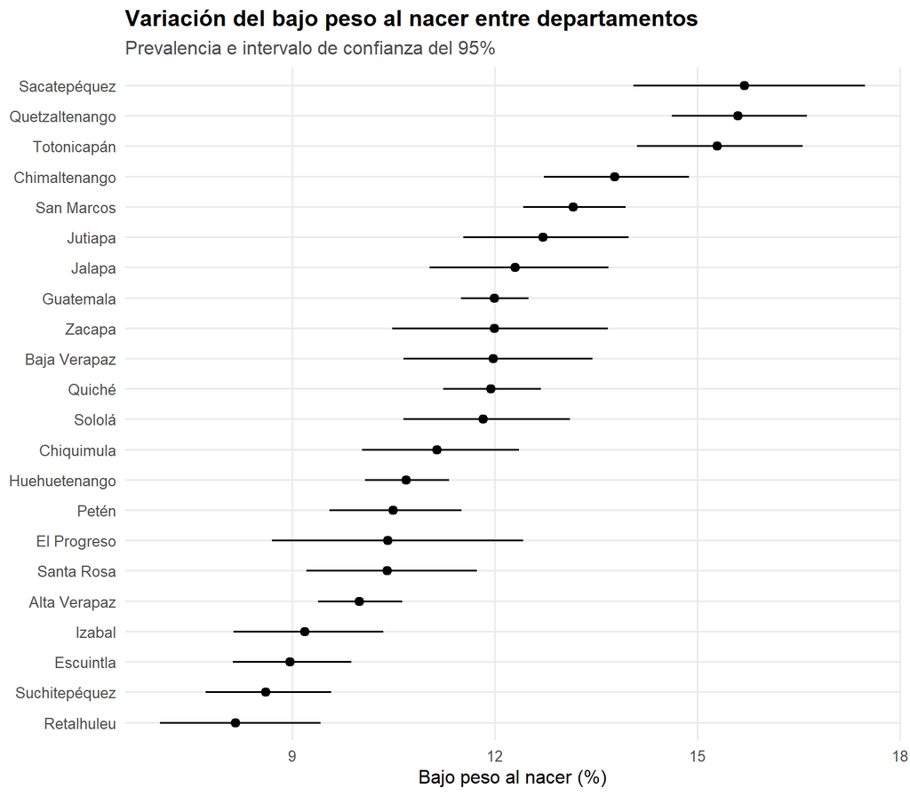

Figura 5: Prevalencia de bajo peso al nacer por departamento de residencia materna.

```r
resumen_departamental <- resumir_lbw(
  base,
  maternal_department_name
) |>
  arrange(prevalencia) |>
  mutate(
    maternal_department_name = factor(
      maternal_department_name,
      levels = maternal_department_name
    )
  )

ggplot(
  resumen_departamental,
  aes(
    y = maternal_department_name,
    x = prevalencia
  )
) +
  geom_segment(
    aes(
      x = li95,
      xend = ls95,
      yend = maternal_department_name
    ),
    linewidth = 0.55
  ) +
  geom_point(
    size = 2.3
  ) +
  labs(
    x = "Bajo peso al nacer (%)",
    y = NULL,
    title = "Variación del bajo peso al nacer entre departamentos",
    subtitle = "Prevalencia e intervalo de confianza del 95%"
  ) +
  tema_grafico
```

La Figura 5 permite ordenar los territorios según su prevalencia simulada y explorar heterogeneidad espacial.

**Edad materna**

**Ver código**

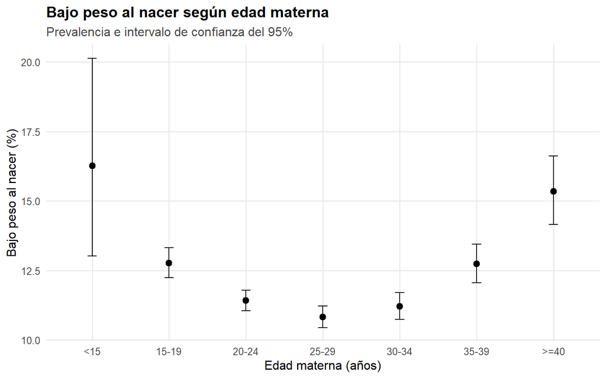

Figura 6: Prevalencia de bajo peso al nacer según grupo de edad materna.

```r
orden_edad <- c(
  "<15",
  "15-19",
  "20-24",
  "25-29",
  "30-34",
  "35-39",
  ">=40"
)

resumen_edad <- base |>
  filter(
    !is.na(maternal_age_group)
  ) |>
  mutate(
    maternal_age_group = factor(
      maternal_age_group,
      levels = orden_edad
    )
  ) |>
  resumir_lbw(
    maternal_age_group
  )

ggplot(
  resumen_edad,
  aes(
    x = maternal_age_group,
    y = prevalencia
  )
) +
  geom_errorbar(
    aes(
      ymin = li95,
      ymax = ls95
    ),
    width = 0.12,
    linewidth = 0.5
  ) +
  geom_point(
    size = 2.5
  ) +
  labs(
    x = "Edad materna (años)",
    y = "Bajo peso al nacer (%)",
    title = "Bajo peso al nacer según edad materna",
    subtitle = "Prevalencia e intervalo de confianza del 95%"
  ) +
  tema_grafico
```

La Figura 6 explora la distribución del bajo peso al nacer a lo largo de los distintos grupos de edad materna.

## Datos ausentes

Los valores ausentes en características maternas se conservaron cuando no impedían responder las preguntas principales. En la muestra analítica, el porcentaje de datos ausentes es de **0.7 %** para edad materna, **1.9 %** para educación, **2.4 %** para pertenencia indígena y **1.5 %** para estado marital.

Esta decisión evita aplicar una eliminación por casos completos a variables que no son necesarias para todos los análisis.

**TipExploración inicial**

Este documento corresponde a una primera exploración de Quarto aplicada al proyecto. Su objetivo es probar un flujo en el que los datos, los cálculos, el texto y las visualizaciones se actualicen de forma reproducible al volver a renderizar el archivo.

## Próximos pasos

Las siguientes etapas contemplan ampliar la descripción de las características maternas y del nacimiento, revisar otras comparaciones territoriales y consolidar la estructura del documento como base del informe final del proyecto.